# HW_2 SP2026 ExpDes_StatMod_2

David Falk

Due: Friday, April 24 at 11:59pm

Points: 244

Topics: Linear and Polynomial Regression, Multiple Regression, Causal Modeling

Please turn in this assignment on Canvas. You should turn in your .Rmd file, i.e., your R markdown file, as well as the corresponding .html or .pdf file (i.e., the knitted Rmarkdown file).

**If you worked with someone on these homework please list them here:**

Worked with: NA

AI disclosure. In 150 words or less, please describe how you used AI on this assignment. You can have the AI that you used generate how it was used for this assignment:  
Used AI for 0.Used it to screw up my computer and then unscrewup my computer. I am grateful the AI can do both. I used VS Code last week and messed up my R env system in the process. 1. Remembering dagitty syntax for coordinates 2. Double checking my linear algebra setup for 3F (design matrix with cubic term no squared term) 3. Sanity checkinginterpretation the Simpson’s paradox result in Q9. All writing/interpretation is mine.

# Question 1: Inferential uncertainty

## Q1A. People often confuse confidence intervals around the mean (inferential stats) vs. confidence intervals around individual observations and think the intervals around the mean applies to individual observations. According to Zhang et al. (2023), does this cause people to over- or under-estimate their effect sizes? (2 points)

*Write your answer in the lines below:*

They overestimate their effect sizes. The CI around the mean shrinks as you add more data (SE = standard_dev/sqrt(n)), so the interval around the mean is always narrower than the actual variation in the data. If you confuse the two then you might end up thinking the separation between conditions is cleaner than it really is at the level of individual people.

## Q1B. Related to this, does this confusion lead people to over- or under-estimate how predictive their models are at predicting individual observations? (2 points)

*Write your answer in the lines below:*

Overestimate. If you read a narrow CI around the mean as if it tells you where individual observations will land, then you think your model is nailing individual predictions when really its only telling you about where the average sits. The actual interval of interest for a single observation is much wider than the CI around the mean because SE is just sigma divided by sqrt(n) and any time n > 1 & stdev > 0 you have that mean +- SE is a strict subset of mean +- sigma.

# Question 2: Interpreting Posteriors

The following code produces the figure 4.10 from McElreath.

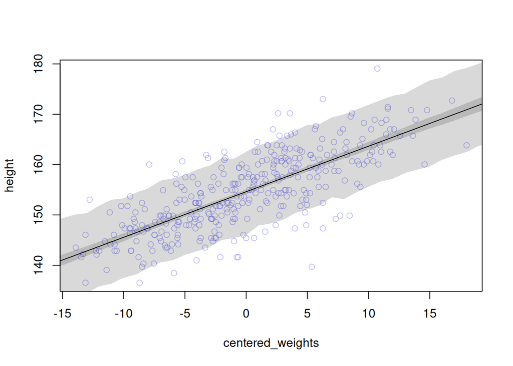

```r
# Loading in Howell1
data(Howell1)

# Assign it to d
d <- Howell1

# Restrict to adults
d2 <- d[d$age >= 18, ]

# Let xbar be the mean weight
xbar <- mean(d2$weight)

# Center weights around the mean
d2$centered_weights <- d2$weight - xbar


# Fit model
# ==========================================================================
# Set the seed for reproducability
set.seed(2026)

# Fit model via quap
m4.3 <- quap(
    alist(

        # Let height be modelled around a normal distribution of mean mu
        #   and standard deviation sigma
        height ~ dnorm(mu , sigma),

        # Let mean mu be given by some degree one polypomial of the form...
        #   weight * weight_height_slope + intercept
        mu <- a + b * (centered_weights),

        # Let's guess some vaguely average height for the intercept
        #   as the intercept (x = 0) is when weight is average
        a ~ dnorm(178 , 20),

        # Get the slope as log normal dist (right skewed) w log(mean) = 0 and log(std) = 1
        b ~ dlnorm(0 , 1),

        # Let std be from uniform distribution with min 0 and max 50
        # so we get pdf(x) = 1 / 50
        sigma ~ dunif(0 , 50)
    ) , data = d2)
# ==========================================================================

# define sequence of weights to compute predictions for
# these values will be on the horizontal axis
# Gonna use this as a set of (centered) weights to calculate predictions for
#   when we pull samples (a, b, sigma) from our posterior
weight.seq <- seq(from = -20 , to = 20 , by = 1)

# Simulate posterior observations using the quap model:
# UNDER THE HOOD
# ==============
# Let s = 1,...,S index the posterior draws (a_s, b_s, sigma_s)
# Let w_i in {-20, -19, ..., 19, 20}
#
# 1. Draw (a_s, b_s, sigma_s) for s = 1,..., S from the posterior
#
# 2. For each s and each w_i calculate the expected height:
#        mu_{s,i} = a_s + b_s * w_i
#
# 3. For each (s, w_i) draw one sample from a Normal dist with mu_{s,i}, sigma_s:
#        h_{s,i} ~ Normal(mu_{s,i}, sigma_s)
#
# Result:
#   Matrix H = (h_{s,i}) of size S x 41
#
# A single cell: A given cell represents the sample height drawn from the normal
#                   distribution with mean = mu_{s,i} = a_s + b_s * w_i and std = sigma_s
#
# Rows: As you move left to right across a given row you have the sample heights
#         for a fixed posterior draw (a_s, b_s, sigma_S) over all 41 weights
#
# Columns: As you move down a given column you see get the sample heights at
#             for a fixed weight w_i over all posterior draws
# Interpretation:
#   For each fixed w_i, {h_{s,i}}_{s=1}^S approximates p(height | w_i, data)
sim.height <- sim(m4.3, data = list(centered_weights = weight.seq))

# Summarize sim() data
height.PI <- apply(sim.height, 2, PI, prob = 0.89)


# Now for a given weight w_i, we can get a family of linear models for predicting
#   that weight.
# We do this by generating new samples from the posterior. Lets index these via
#   s_new = 1, ..., S_new and draw (a_s, b_s, sigma_s) from the posterior for s in {1, ..., S_new}.
# Using these new samples and our fixed weight w_i, we calculate mu_{s, i} = a_s + b_s * w_i
#   which gives us a distribution of expected heights at a given weight. This can
#   be represented as dist_i = [mu_{s, i}] for s in {1, ..., S_new}.
# We then interpret dist_i as approximating p(mu | w_i, data)
mu <- link(m4.3, data = data.frame(centered_weights = weight.seq))

# At this point we have...

# LINK() - p(mu | w_i, data) - Used for estimating our linear relationships
#     mu = a + b * w_i
# =================================================================
# A family of samples of mu for each weight which approximates p(mu | w_i, data)

# SIM() - p(height∣w_i, data) - Used for estimating height
# =================================================================
# A matrix of samples of height generated by first sampling the posterior, finding the
#   expected height (mu) that each sample predicts at each weight, and then sampling
#   a height from a normal distribution around that weight's expected height
#   for each sample from the posterior. This approximates p(height∣w_i, data)

# So we use link to estimate the mean and data about the mean
# and we use sim to estimate individual heights (link + noise around mean at given centered weights)

# Summarize link data
mu.mean <- apply(mu, 2, mean)
mu.PI   <- apply(mu, 2, PI, prob = 0.89)
mu.HPDI <- apply(mu, 2, HPDI)

# plot heights vs. centered weights
plot(height ~ centered_weights, d2 , col = col.alpha(rangi2, 0.5))

# draw MAP line
lines(weight.seq, mu.mean)

# draw HPDI region for line
shade(mu.HPDI, weight.seq)

# draw PI region for simulated heights
shade(height.PI, weight.seq)
```

## Q2A. What does the narrower shaded interval represent?

*Write your answer in the lines below:*

The narrower band is the HPDI for mu, so it is the smallest interval containing a proportion p of the posterior density p(mu | w_i, data) for each w_i where w_i is a weight in [-20, -19, …, 19, 20]. If I’m not mistaken the “shade(mu.HPDI, weight.seq)” is interpolating each of the HPDI’s around each w_i so it looks continuous even though the underlying numbers for each band ought to be discrete intervals around each w_i. Each is calculated as the narrowest band containing some proportion p of the posterior distribution p(mu | w_i, data). It tells you where the regression line itself most plausibly sits given the data, not where individual people are.

## Q2B. What does the wider shaded interval represent?

*Write your answer in the lines below:*

The wider band is the 89% PI of simulated heights, which is the predictive interval for individual observations. It captures uncertainty in the mean PLUS the sigma noise around the line, so for a fixed weight it can be interpretted as a plausible range where you’d expect an actual person’s height to land.

## Q2C. What makes the narrower interval narrower, and the wider interval wider?

*Write your answer in the lines below:*

The narrower one only reflects uncertainty in the posterior over a and b (the line itself). As you add more data that uncertainty shrinks and the interval gets tighter. The wider one has to include sigma on top of that, which is the natural variation of individuals around the mean, and that does NOT necessarily shrink when you add more data, as there is always natural variation around a mean. So one is about “where is the line” (shrinks accd to sqrt(n)) and the other is “where are people” (“where is the line” +- the effect of sigma).

## Q2D. The posterior distribution has how many parameters in it? What do those parameters describe?

*Write your answer in the lines below:*

3 parameters: a, b, and sigma. a is the intercept, which with centered weight is the mean height of an adult at the average weight. b is the slope, the expected unit in height for a unit increase in weight. sigma is the std of heights around the regression line, i.e. how much individual heights deviate from the predicted mean at a given weight.

# Question 3: Predicting Height from Weight

The following code (modified from 4.65 in McElreath) creates a model that predicts height from weight.

```r
## adapted R code 4.65

# z score the weights
d$weight_s <- ( d$weight - mean(d$weight) )/sd(d$weight)

# cube the z-scored weights
d$weight_s3 <- d$weight_s^3
set.seed(2026)

# Fit linear model where height via normal dist on mu and sigma
# mu becomes a function of b1 and b3 and is a cubic with no degree 2 term
# take b1 as log normal distribution:
#     right skewed and positive
#     Importing the idea that weight has a positive effect on height?
# take b3 as normal distribution:
#     Cubic term typically interpretted to effect curvature, so minimal assumption make sense
# At a given weight w we'd have a derivative of h'(x) = b1 + (3 * b3 * w^2)
m4.5 <- quap(
    alist(
        height ~ dnorm( mu , sigma ) ,
        mu <- a + b1*weight_s + b3*weight_s3 ,
        a ~ dnorm( 178 , 20 ) ,
        b1 ~ dlnorm( 0 , 1 ) ,
        b3 ~ dnorm( 0 , 1 ) ,
        sigma ~ dunif( 0 , 50 )
    ) , data=d )

# Summarize the model
precis(m4.5)
```

```
##             mean        sd       5.5%      94.5%
## a     141.396827 0.3399147 140.853578 141.940077
## b1     14.033891 0.6752930  12.954643  15.113140
## b3      5.782959 0.2931167   5.314502   6.251416
## sigma   7.016575 0.2136360   6.675143   7.358006
```

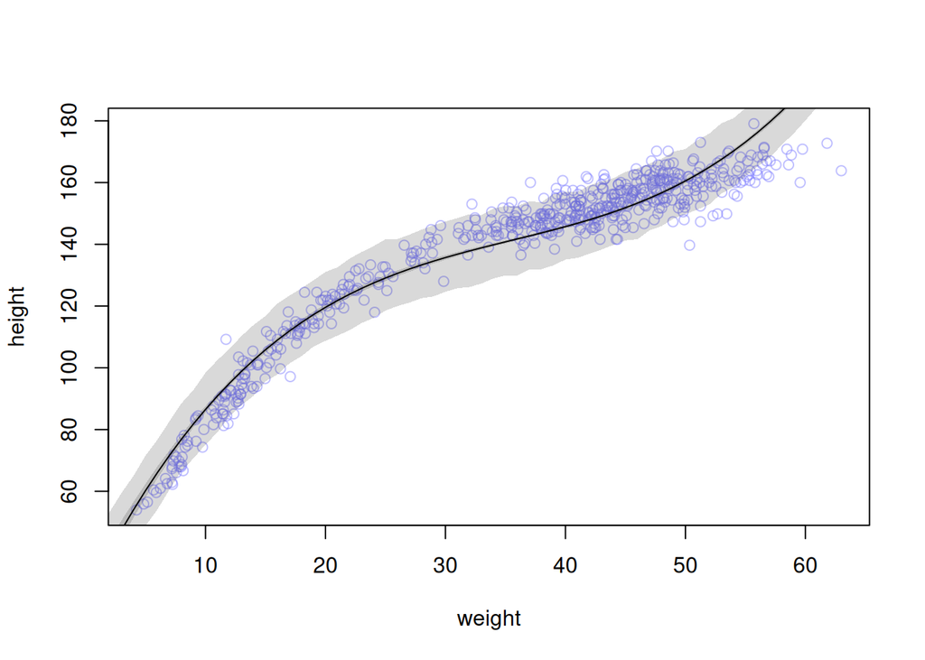

```r
# just follow above code this gives stuff to test over
weight.seq.m4.5 <- seq( from=1 , to=70 , by=1 )

# zscore for consistency
weight_s.seq.m4.5 <- ( weight.seq.m4.5 - mean(d$weight) )/sd(d$weight)
weight_s3.seq.m4.5 <- weight_s.seq.m4.5^3

fit_data = data.frame(list(weight_s=weight_s.seq.m4.5,
                           weight_s3=weight_s3.seq.m4.5))

sim.height.m4.5 <- sim( m4.5 , data=fit_data )

height.PI.m4.5 <- apply( sim.height.m4.5 , 2 , PI , prob=0.89 )

mu.m4.5 <- link( m4.5 , data=fit_data )

mu.mean.m4.5 <- apply( mu.m4.5 , 2 , mean )
mu.PI.m4.5 <- apply( mu.m4.5 , 2 , PI , prob=0.89 )
mu.HPDI.m4.5 <- apply(mu.m4.5, 2, HPDI)

plot( height ~ weight , d , col=col.alpha(rangi2,0.5) )

lines( weight.seq.m4.5 , mu.mean.m4.5 )

shade( mu.HPDI.m4.5 , weight.seq.m4.5 )

shade( height.PI.m4.5 , weight.seq.m4.5 )
```

## Q3A. Using the code above, write out the full regression model (look at the exponents carefully)

*Write the equation here:* for observation, let’s call it person_i where i in [1, …, num_datapoints] we get… height_i ~ Normal(mu_i, sigma) mu_i = a + b1 * weight_s_i + b3 * weight_s_i^3 a ~ Normal(178, 20) b1 ~ LogNormal(0, 1) b3 ~ Normal(0, 1) sigma ~ Uniform(0, 50)

Note: there is no b2 * weight_s^2 term

## Q3B. What are the units of b1 and b3?

*Write your answer in the lines below:*

weight_s is z-scored weight so it is unitless (std devs of weight away from the mean). height is in cm. b1 has units of cm per unit of standardized weight (cm per std dev of weight). b3 has units of cm per (standardized weight)^3.

## Q3C. How many parameters are in the posterior distribution? These parameters compose what kind of function?

*Write your answer in the lines below:*

4 parameters: a, b1, b3, sigma. a, b1, b3 compose the mean function (deterministic part of mu), which is a cubic polynomial operating over weight_s (with quadratic coefficient set to 0). sigma is the std of the Gaussian noise around that curve.

## Q3D. Set your seed to 2026 and fit another model with only a linear component to these data using quadratic approximation. Save this model as “mod3_quap” and output the summary using the precis() function. Plot the model using the code we provided above and compare.

```r
# TODO: Double check this
#mod3_quap

# Set seed
set.seed(2026)

# Same setup as m4.5 but no cubic term
mod3_quap <- quap(
    alist(
        height ~ dnorm(mu , sigma),
        mu     <- a + b1 * weight_s,
        a      ~ dnorm(178, 20),
        b1     ~ dlnorm(0 , 1),
        sigma  ~ dunif(0 , 50)
    ) , data   = d)

# Output summary
precis(mod3_quap)
```

```
##             mean        sd       5.5%      94.5%
## a     138.279545 0.4006252 137.639269 138.919822
## b1     25.942597 0.4012326  25.301350  26.583844
## sigma   9.345954 0.2833448   8.893114   9.798793
```

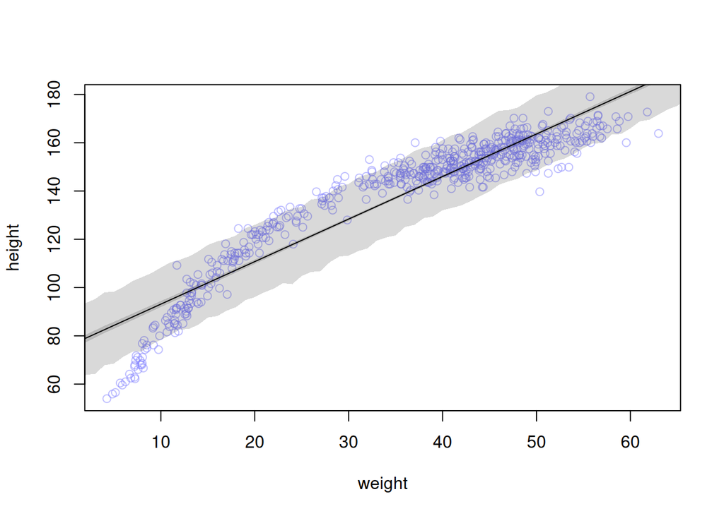

```r
# Use the same weight sequence as above
weight.seq.mod3 <- seq(from = 1, to = 70, by = 1)
weight_s.seq.mod3 <- (weight.seq.mod3 - mean(d$weight)) / sd(d$weight)

# Only need weight_s for the linear model (no cubic)
fit_data_mod3 = data.frame(list(weight_s = weight_s.seq.mod3))

# Simulate heights for PI
# This is link + noise roughly speaking
# gives us p(height | w_i, data) values
sim.height.mod3 <- sim(mod3_quap, data = fit_data_mod3)
height.PI.mod3 <- apply(sim.height.mod3, 2, PI, prob = 0.89)

# link for mu
# gives us p(mu | w_i, data) values
mu.mod3 <- link(mod3_quap, data = fit_data_mod3)
mu.mean.mod3 <- apply(mu.mod3, 2 , mean)
mu.HPDI.mod3 <- apply(mu.mod3, 2, HPDI)

# Plot same way as b4
plot(height ~ weight, d, col = col.alpha(rangi2, 0.5))

lines(weight.seq.mod3, mu.mean.mod3)

shade(mu.HPDI.mod3, weight.seq.mod3)

shade(height.PI.mod3, weight.seq.mod3)
```

## Q3E. Does the linear + cubic model fit the data better than a model that only had the linear component? Please show/explain how it is or isn’t a better fit.

*Write your answer in the lines below:*

Yes the linear + cubic model fits better. You can see this in the plots: the straight line from mod3_quap misses the actual shape of the data because the relationship between weight and height does not appear linear across the full range (kids with very low weight are much shorter than a straight line would predict, and the curve flattens out for adults and is largely linear, and you can see the cubic misses the top end of weight range wheras a linear model might represent that more faithfully when the data is restricted to adults). The cubic model bends to follow the data and the HPDI/PI bands hug the real observations much more closely. You can also see it in precis: sigma for mod3_quap is larger than for m4.5, meaning there is more leftover variation around the linear line than around the cubic curve, which is consistent with the linear model being a worse fit.

## Q3F. Solve for a, b1 and b3 using linear algebra (hint: use the linear algebra functions from HW1). Save the calculated parameter values as “params_algebra” and output these values.

```r
#params_algebra

# Get pseudoinverse function
library(MASS)
# Build design matrix with columns [intercept, weight_s, weight_s^3]
# Note: no squared term since the model skips it
intercept_column <- rep(1, nrow(d))
weight_s_col     <- d$weight_s
weight_s3_col    <- d$weight_s3

# Stack into X
X <- cbind(intercept_column, weight_s_col, weight_s3_col)

# y is just height
y <- d$height

# get vals via pseudoinverse
params_algebra <- ginv(t(X) %*% X) %*% t(X) %*% y

# Print
params_algebra
```

```
##            [,1]
## [1,] 141.648894
## [2,]  13.065049
## [3,]   6.264792
```

## Q3G. Do your calculated parameters from 3f match the parameters from the quap model?

*Write your answer in the lines below:*

They are very close but not exactly identical. The quap values for a, b1, b3 are similar to the linear algebra estimates. The a terms are basically identical (both around 141), the b^1 term from quap was ~14 and this one is ~13.1, and the b^3 term in quap was 5.8 while this is ~6.3. My guess is that the differences come from the priors pulling the quap estimates slightly toward the prior means (a ~ Normal(178,20), b1 ~ LogNormal(0,1), b3 ~ Normal(0,1)). However there is a lot of data and somewhat loose prirors so I think that is why they basically match.

## Q3H. Fit the model from 3a using the lm() function. Call this “mod3_lm” and output the summary (2 points). Do your calculated parameters from 3f match the parameters from lm?

```r
#mod3_lm

# Fit same model with lm (no priors so this should match linear algebra exactly)
mod3_lm <- lm(height ~ weight_s + weight_s3, data = d)

# Output summary
summary(mod3_lm)
```

```
##
## Call:
## lm(formula = height ~ weight_s + weight_s3, data = d)
##
## Residuals:
##     Min      1Q  Median      3Q     Max
## -42.456  -3.882   0.935   4.775  17.060
##
## Coefficients:
##             Estimate Std. Error t value Pr(>|t|)
## (Intercept) 141.6489     0.3430  412.96   <2e-16 ***
## weight_s     13.0650     0.6958   18.78   <2e-16 ***
## weight_s3     6.2648     0.3045   20.57   <2e-16 ***
## ---
## Signif. codes:  0 '***' 0.001 '**' 0.01 '*' 0.05 '.' 0.1 ' ' 1
##
## Residual standard error: 7.02 on 541 degrees of freedom
## Multiple R-squared:  0.9356, Adjusted R-squared:  0.9353
## F-statistic:  3927 on 2 and 541 DF,  p-value: < 2.2e-16
```

*Write your answer in the lines below:*

Yes, these match almost exactly (up to rounding). lm is doing the same ordinary least squares calculation that the Moore-Penrose pseudoinverse does when X^T X is invertible, so the intercept, b1 (weight_s coef) and b3 (weight_s3 coef) from lm line up with params_algebra.

**The code below performs a prior predictive check for a model predicting height using age for children.**

```r
# Restrict to adults, set n to 20
d3 = d[d$age<18, ]
N = 20

# Generate 20 random deviate data points w mean 100 and std 20
a = rnorm(N, 100, 20)

# Generate 20 rand deviate data points with exp rate of 1
# so positive slopes w right skew
b = rexp(N, 1)

# Plot ages on x-axis, height on y-axis and for each deviate generated
#   plot a line with from our generated datapoints
# This should work bc we center the ages so when x = x_bar we get just a[i]
#   since our formila is pred_height[i] = a[i] + b[i] * (x - x_bar)
plot(NULL, xlim = range(d3$age), ylim = c(0, 200), xlab="age", ylab="height")
xbar = mean(d3$age)
xbar
```

```
## [1] 7.721875
```

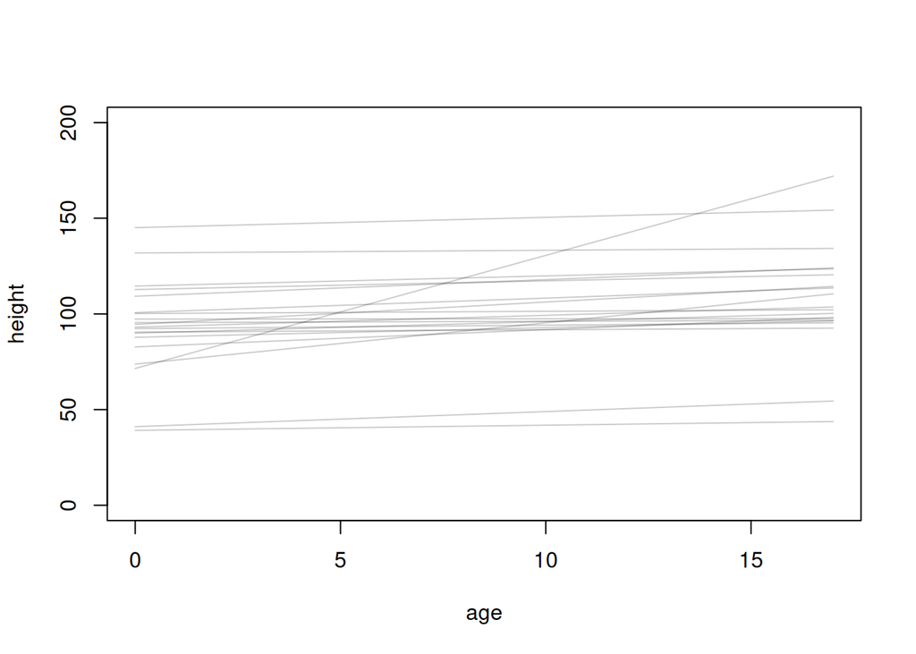

```r
for(i in 1:N) {
    curve(a[i] + b[i] * (x - xbar), from = min(d3$age), to = max(d3$age),
          add=TRUE, col=col.alpha("black", 0.2))
}
```

## Q3I. What problem with our priors is revealed thanks to this prior predictive check? What could we do to change our priors to address this issue?

*Write your answer in the lines below:*

Remember: on this graph each line should cross its intercept at the average age (which is 7.72)

The prior lines have positive slopes (b is Exponential(1) so always positive which is fine, kids do grow taller with age), but the intercept prior Normal(100, 20) is too wide. Some of the sampled intercepts come out pretty low and imply implausibly short children at the average age (e.g. 18 inches at age 7 which sounds cute and perhaps a little funny but may be serious), and most of the slopes are shallow enough that the line basically flatlines and suggest people don’t really grow.

Fix: tighten the intercept prior to something centered closer to the actual mean height of kids at the mean age (like Normal(130, 10) or wherever the data suggests) and use a slope prior that has a better range of slopes because almost all of them are really flat (like LogNormal so we stay away from both near zero and crazy steep slopes). Basically pick priors that don’t generate impossible kids before seeing any data.

## Q3J. Now let’s perform another prior predictive check for our model above (m4.5), which predicts height from weight (we’ll pretend that we haven’t fit the data to the model yet). We’ll simulate 50 regression lines implied by the priors alone. Some of the code below is taken from the textbook (R code 5.4, page 126)

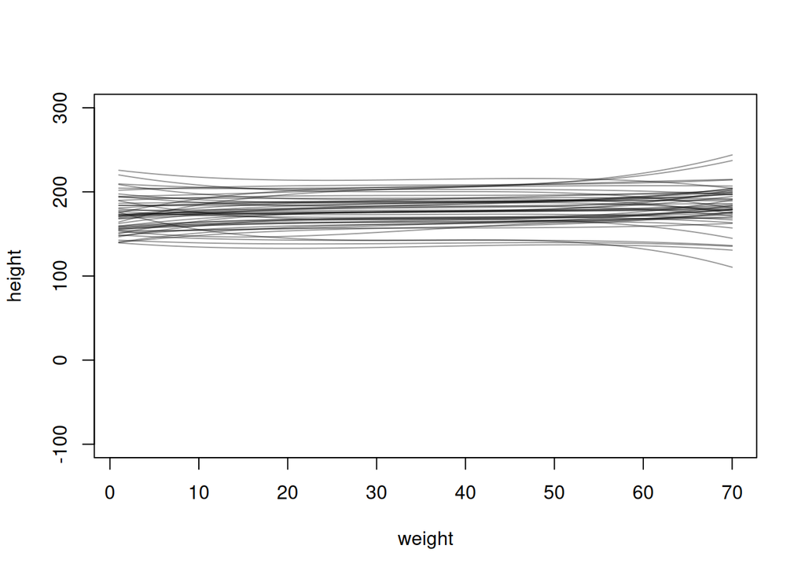

```r
# Sample from your priors using extract.prior() and call it "prior"
prior <- extract.prior(m4.5)

# Just as above, we'll define sequence of weights to compute predictions for
# These values will be on the horizontal axis
weight.seq.m4.5 <- seq( from=1 , to=70 , by=1 )
weight_s.seq.m4.5 <- ( weight.seq.m4.5 - mean(d$weight) )/sd(d$weight) # Standardized
weight_s3.seq.m4.5 <- weight_s.seq.m4.5^3 # For cubic term

fit_data = data.frame(list(weight_s=weight_s.seq.m4.5,
                           weight_s3=weight_s3.seq.m4.5))


# Again, just as above, we'll use link() to compute mu for each sample from our *prior*
# and for each weight in weight.seq
sample_mu <- link( m4.5 ,
                   post=prior,
                   data=fit_data )

# Plot
plot( NULL , xlim=c(1, 70) , ylim=c(-100, 300) , xlab="weight", ylab="height")

for ( i in 1:50 ) {
  lines( weight.seq.m4.5 , sample_mu[i,] , col=col.alpha("black",0.4) )
}
```

Do the priors allow for implausible heights? If so, suggest a modification to make the priors more reasonable.  
*Write your answer in the lines below:*

Yes there are plenty of implausible heights. Some of the predicted heights fall in a reasonable range, but the implied relationships between weight and height are not very realistic. Many of the curves are nearly flat, suggesting little change in height as we modulate weight. This indicates that the priors on the coefficients (b1 and b4) are too weakand result in improbable shapes for the relationship. To fix this we could use priors that are looser or we could use data driven priors to get better estimates of the shape of the curve.

# Question 4: Splines vs. Polynomial Regression

**What is the main advantage of using splines over polynomial regression? What is a disadvantage of using a spline?** *Write your answer in the lines below:*

Main advantage: splines are local and give you better control over your fit. A spline is made of piecewise polynomial functions where each piece defines the model over a particular interval of the domain. The result is that a weird chunk of data in one region doesn’t mess up the fit in another region because you can add a piecewise polynomial over that “weird” interval. Polynomial regression defines a single polynomial over the entire domain (“global”): every data point affects the whole curve everywhere, and high degree polynomials struggle at extremal values (Runge’s phenomenon). Splines give you flexibility without that global instability.

Disadvantage: you have to choose knots (where they go, how many) and the degree of each piecewise function, and those choices are kind of arbitrary/fussy so you are potentially smuggling in biases or making mistakes in these choices. If you struggle fitting one polynomial then a spline may be trouble. Too many knots and you overfit, too few and you underfit. Also splines are less interpretable as an equation: “height can be modeled as an intercept plus b1 times weight plus b3 times weight cubed” is a sentence people like hearing, while “height can be modeled as set of basis weights over the M-dimensional Reals with domain W and K as a subset of W is our knot set” is harsher on the ears.

# Question 5: Adding Predictors to a Model

**Is it always a good idea to add all potential predictor variables that you can think of into a multiple regression? When will adding predictors help? When will it hurt inference?** *Write your answer in the lines below:*

No, it is not always a good idea. Adding predictors will help when true causal influences on the outcome that you are NOT already capturing, or when they block a backdoor path that would otherwise produce spurious associations.

It will hurt inference in several cases. First, if you include a post-treatment variable (something downstream of your treatment) you end up controlling away the effect you were trying to measure (mediators eat your effect). Second, if you include a collider you actually open up a spurious path and introduce confounding that wasn’t there before. Third, just adding lots of noisy predictors eats degrees of freedom and can overfit. So the right set of predictors is guided by causal structure, not by dumping everything into the regression.

# Question 6: Spurious Correlations, Masked Relations

The code below will create data for a spurious correlation, where the variable x_spur is spuriously correlated with y.

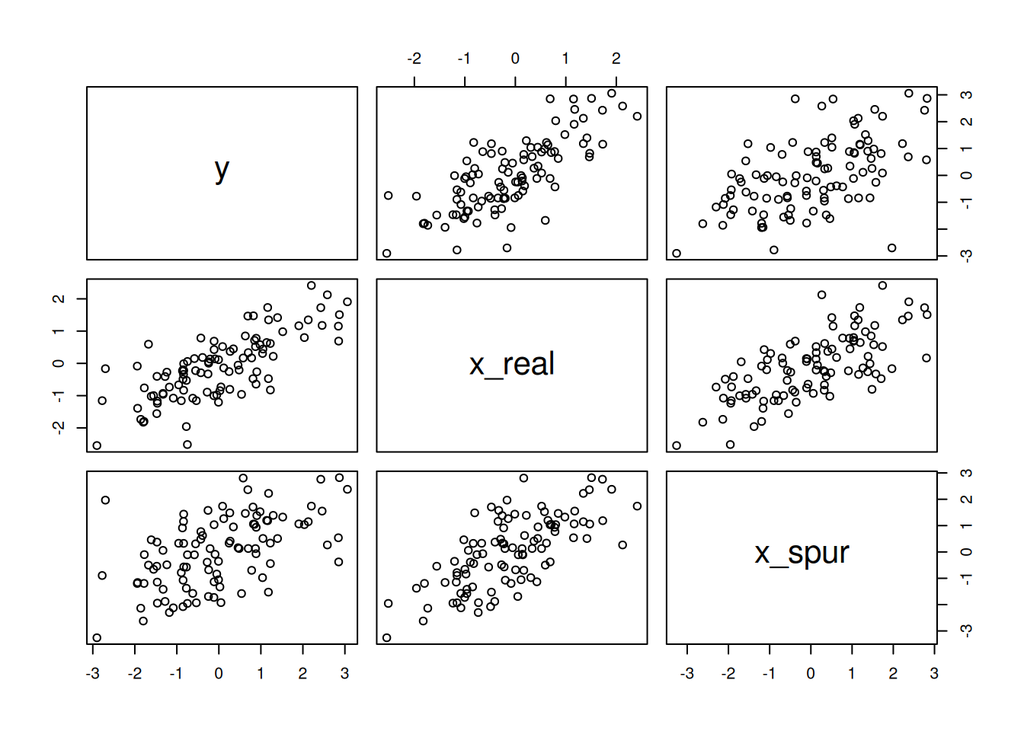

```r
set.seed(2026)
N <- 100   #number of cases
x_real <- rnorm(N) #x_real as Gaussian with mean = 0 and std = 1
x_spur <- rnorm(N, x_real) #x_spur as Gaussian with mean = x_real
y <- rnorm(N, x_real) #y as Gaussian with mean = x_real
d <- data.frame(y, x_real, x_spur) #bind them all together
#make a scatterplot
pairs(d)
```

## Q6A. Please draw a DAG for this spurious relationship using the daggity package. Call this DAG “dag_6A”.

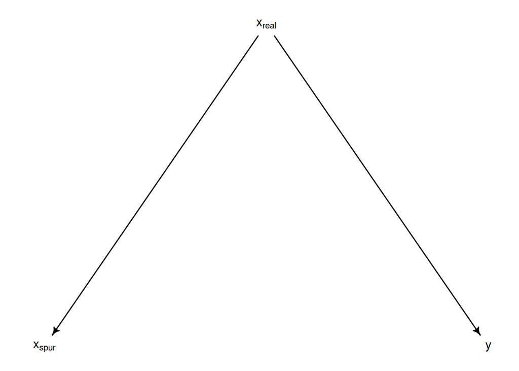

```r
#dag_6A <- dagitty( "dag{  }" )   # setting up the DAG using dagitty()
#coordinates(dag_6A) <- list( )   # specify the coordinates in your DAG
#drawdag( dag_6A )    # draw the DAG

# x_real drives both x_spur and y, so x_spur looks correlated with y but only through x_real
dag_6A <- dagitty("dag{ x_real -> x_spur ; x_real -> y}")
coordinates(dag_6A) <- list(x = c(x_real = 1, x_spur = 0, y = 2) , y = c(x_real = 0, x_spur = 1, y = 1))
drawdag(dag_6A)
```

The code below will create data of a masked relationship between x and y.

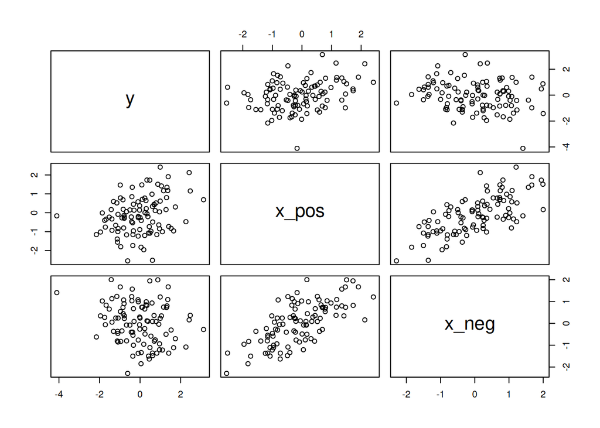

```r
set.seed(2026)
N <- 100     #number of cases
rho <- 0.7   #correlation between predictors x_pos and x_neg
x_pos <- rnorm(N) #x_pos as Gaussian
x_neg <- rnorm(N, rho*x_pos, sqrt(1-rho^2)) #x_neg correlated with x_pos
y <- rnorm(N, x_pos - x_neg) # difference of x pos and x neg

d <- data.frame(y, x_pos, x_neg) #bind it all together
pairs(d)
```

## Q6B. Now draw a DAG for this masked relationship using the daggity package. Call this DAG “dag_6B”.

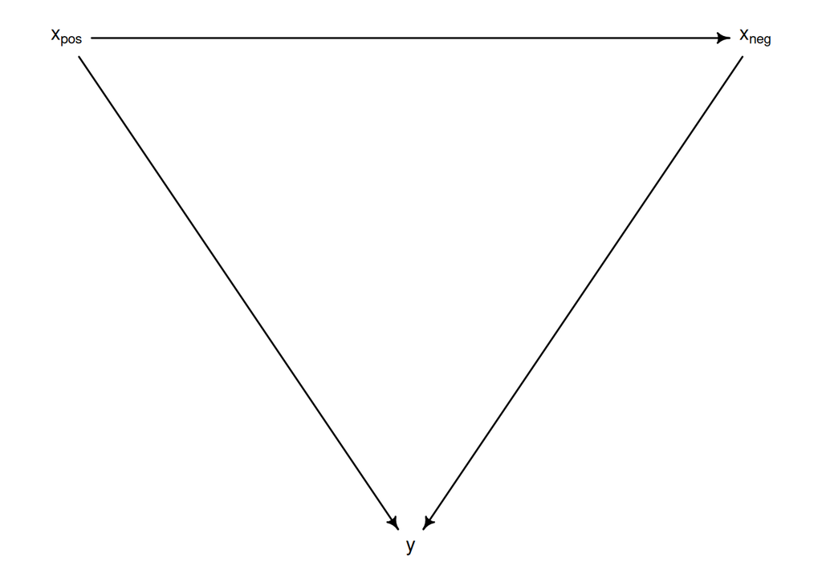

```r
#dag_6B

# x_pos and x_neg are correlated, and both cause y (with opposite signs)
# In the sim code x_neg is literally generated from x_pos so I'll draw x_pos -> x_neg
# plus both -> y
dag_6B <- dagitty("dag{x_pos -> x_neg; x_pos -> y; x_neg -> y}")
coordinates(dag_6B) <- list(x = c(x_pos = 0, x_neg = 2, y = 1), y = c(x_pos = 0, x_neg = 0, y = 1))
drawdag(dag_6B)
```

## Q6C. What is the difference in the correlation structure, i.e., the correlation matrix between a spurious correlation and a masked correlation?

*Write your answer in the lines below:*

In the spurious case, the correlation matrix shows BOTH predictors correlated with y (even though only x_real actually drives y, x_spur looks correlated with y because of their shared cause). In the masked case, the correlation matrix shows each predictor has weak or near-zero correlation with y on its own, even though both of them actually drive y. The two opposing effects cancel out, so the pairwise correlations hide the real relationships. You’d only see the true effects when you include both predictors together in the regression.

## Q6D. How does changing rho, the correlation between the predictors x_neg and x_pos, change the amount of masking? To answer this question, you will need to fit a model (use lm for ease). Try values of rho = 0.7 and = 0.999. Set your seed to 2026 before *each* simulation.

```r
#Test your values of rho here

# --- rho = 0.7 ---
set.seed(2026)
N <- 100
rho <- 0.7
x_pos <- rnorm(N)
x_neg <- rnorm(N, rho*x_pos, sqrt(1-rho^2))
y <- rnorm(N, x_pos - x_neg)
d_rho7 <- data.frame(y, x_pos, x_neg)

# Bivariate correlations
print("===============================")
```

```
## [1] "==============================="
```

```r
print("RHO = 0.7")
```

```
## [1] "RHO = 0.7"
```

```r
print("===============================")
```

```
## [1] "==============================="
```

```r
cor(d_rho7)
```

```
##                y     x_pos      x_neg
## y      1.0000000 0.2994497 -0.1911188
## x_pos  0.2994497 1.0000000  0.6959056
## x_neg -0.1911188 0.6959056  1.0000000
```

```r
# Multiple regression with both predictors
mod_rho7 <- lm(y ~ x_pos + x_neg, data = d_rho7)
summary(mod_rho7)
```

```
##
## Call:
## lm(formula = y ~ x_pos + x_neg, data = d_rho7)
##
## Residuals:
##     Min      1Q  Median      3Q     Max
## -2.7427 -0.5634 -0.1146  0.5697  2.1214
##
## Coefficients:
##             Estimate Std. Error t value Pr(>|t|)
## (Intercept)  0.09529    0.09010   1.058    0.293
## x_pos        0.95033    0.12421   7.651 1.47e-11 ***
## x_neg       -0.92607    0.13102  -7.068 2.41e-10 ***
## ---
## Signif. codes:  0 '***' 0.001 '**' 0.01 '*' 0.05 '.' 0.1 ' ' 1
##
## Residual standard error: 0.8902 on 97 degrees of freedom
## Multiple R-squared:  0.3992, Adjusted R-squared:  0.3868
## F-statistic: 32.22 on 2 and 97 DF,  p-value: 1.862e-11
```

```r
print("===============================")
```

```
## [1] "==============================="
```

```r
# --- rho = 0.999 ---
set.seed(2026)
N <- 100
rho <- 0.999
x_pos <- rnorm(N)
x_neg <- rnorm(N, rho*x_pos, sqrt(1-rho^2))
y <- rnorm(N, x_pos - x_neg)
d_rho999 <- data.frame(y, x_pos, x_neg)

# Bivariate correlations
print("RHO = 0.999")
```

```
## [1] "RHO = 0.999"
```

```r
print("===============================")
```

```
## [1] "==============================="
```

```r
cor(d_rho999)
```

```
##                 y       x_pos       x_neg
## y     1.000000000 0.002987597 0.003359706
## x_pos 0.002987597 1.000000000 0.999086460
## x_neg 0.003359706 0.999086460 1.000000000
```

```r
# Multiple regression with both predictors
mod_rho999 <- lm(y ~ x_pos + x_neg, data = d_rho999)
summary(mod_rho999)
```

```
##
## Call:
## lm(formula = y ~ x_pos + x_neg, data = d_rho999)
##
## Residuals:
##     Min      1Q  Median      3Q     Max
## -2.7427 -0.5634 -0.1146  0.5697  2.1214
##
## Coefficients:
##             Estimate Std. Error t value Pr(>|t|)
## (Intercept)  0.09529    0.09010   1.058    0.293
## x_pos       -0.17753    2.08721  -0.085    0.932
## x_neg        0.18079    2.09267   0.086    0.931
##
## Residual standard error: 0.8902 on 97 degrees of freedom
## Multiple R-squared:  8.586e-05,  Adjusted R-squared:  -0.02053
## F-statistic: 0.004165 on 2 and 97 DF,  p-value: 0.9958
```

## Q6E. What are the dangers of interpreting a bivariate correlation matrix? What do you really want to know about the relationship between variables?

*Write your answer in the lines below:*

The danger is that a bivariate correlation matrix tells you nothing about causal structure. You can see a strong correlation that is actually spurious (driven by a common cause, like Q6A) and you can miss real effects that are masked by opposing correlated predictors (like Q6B). So correlations overstate relationships in some cases and understate them in others, and you can’t tell which from the matrix alone.

What I actually want to know is the causal structure: which variables cause which, what the DAG looks like, and then conditional on that structure what the direct and indirect effects of each variable are. Once I have a DAG I can choose what to condition on (close backdoors, don’t open colliders) and get something I can actually interpret causally.

# Question 7: Randomized Controlled Experiments & Causal Inference for Non-Experiments

## Q7A. How do randomized controlled experiments allow for causal inference? What do they do to DAG models?

*Write your answer in the lines below:*

RCTs work because when you randomly assign the treatment you physically break any arrows from other variables into the treatment variable. In DAG terms, randomization deletes all incoming edges to the treatment node, so the treatment is independent of any potential confounders by construction. There cannot be a backdoor path from treatment to outcome through some lurking variable because nothing can influence the treatment assignment (it was a coin flip much like in the modified Monty Hall wherein Monty Hall does NOT actually know which door the car is behind and chooses randomly).

That means any association you observe between treatment and outcome has to come through the direct causal path, which is what makes the inference causal rather than just correlational. More specifically, this allows you to measure the TOTAL causal influence over all paths from treatment to outcome.

## Q7B. What needs to be done and what criteria need to be met to draw causal inferences from observational/non-experimental studies?

*Write your answer in the lines below:*

You have to explicitly write out a causal DAG that you think describes the variables and their relationships. Then you need to find a set of variables to condition on that closes all backdoor paths from your predictor of interest to your outcome, without conditioning on colliders (which would open new spurious paths beacuse it forces relationships between variables when they are in fact independent causes of the variables you conditioned on) and without conditioning on post-treatment/mediator variables (which would block the effect and would reduce the measured any effect of treatment on outcome that is mediated via a mediator, and thus you can miss a big part of the effect that you are trying to measure). The main criterion is the backdoor criterion: the set of conditioning variables should block every path from X to Y that starts with an arrow into X, while leaving open the directed causal paths from X to Y. You also have to assume the DAG you wrote down is actually correct (no important unobserved confounders you missed), which is a strong assumption. If the DAG is wrong the causal estimate is wrong.

# Question 8: Interpreting DAGs

**The code below will draw a DAG to be used for part A.**

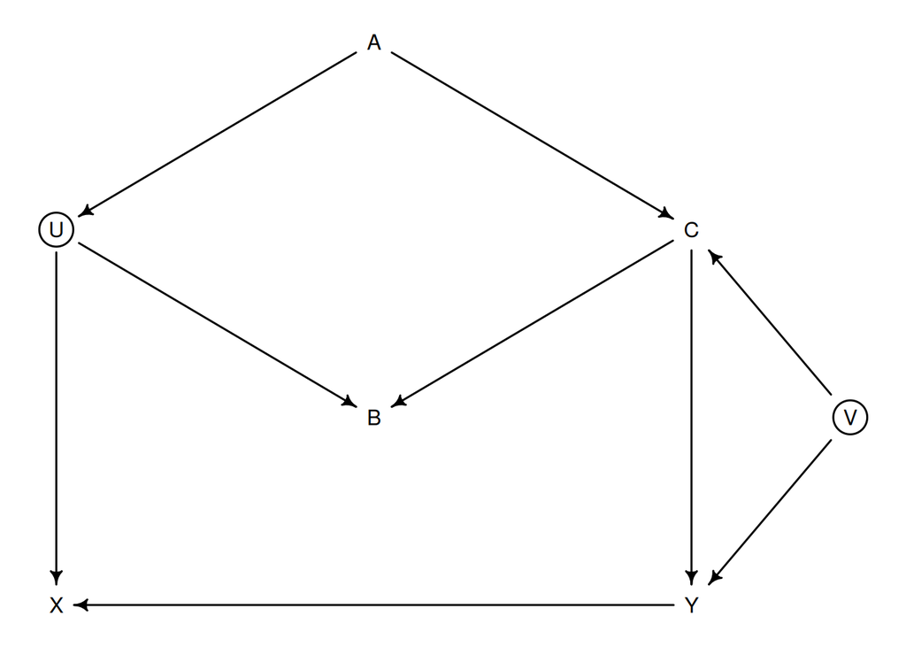

```r
dag_6M1 <- dagitty("dag{
U [unobserved]
V [unobserved]
Y -> X
X <- U -> B <- C -> Y
U <- A -> C
C <- V -> Y }")
coordinates(dag_6M1) <- list(x=c(X=0,Y=2,U=0,A=1,B=1,C=2,V=2.5),
y=c(X=2,Y=2,U=1,A=0.5,B=1.5,C=1,V=1.5) )
drawdag(dag_6M1)
```

## Q8A. What paths, if any, need to be closed to draw causal inferences between the effect of Y -> X? If there are problematic paths how do you close them? What variables would you not want to condition on, if any? In this DAG can we draw a causal inference from Y -> X?

*Write your answer in the lines below:* In general… 1. Treat the graph as if it is adirected and find all paths from Y to X other than (Y -> X). 2. Once you do that then reapply the directed arrows. 3. A path is considered OPEN unless it contains a collider that we are NOT conditioning on. 4. To close a path, then condition on any variable that is observed and NOT a collider (preferably not a descendent of a collider either)

Paths from Y to X (but not Y -> X): 1. Y <- C <- A -> U -> X (through A) 2. Y <- V -> C <- A -> U -> X (V is unobserved, also has a collider at C) 3. Same paths as 1 & 2 but replace A with B.

For #1 we can condition on A since it is observed and not a collider. For #2 C is a collider between A and V (V -> C <- A) so it is already closed assuming we don’t condition For #3 B is a collider between U and C (U -> B <- C) so it’s already closed assuming we don’t condition

Since we can close all backdoor paths from Y to X we can draw causal inferences between Y -> X.

**The code below will draw a DAG to be used for part B.**

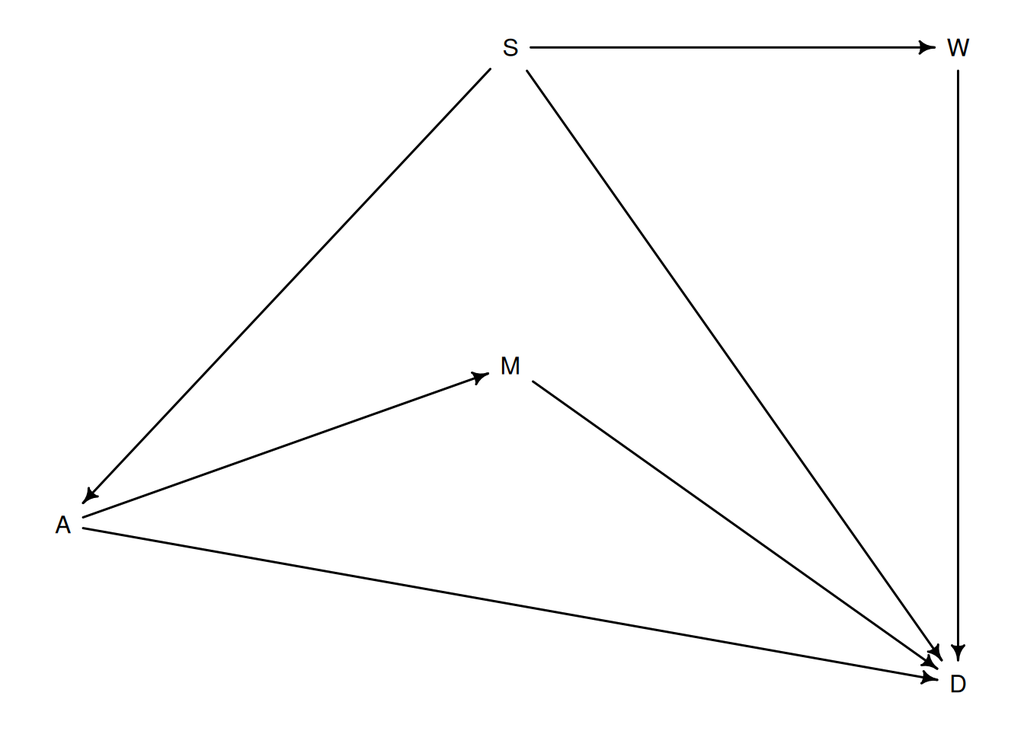

```r
dag_6H1 <- dagitty("dag{A -> D; A -> M -> D; A <- S -> D; S -> W -> D}")
coordinates(dag_6H1) <- list(
x=c(A=0,M=1,D=2,S=1,W=2),
y=c(A=0.75,M=0.5,D=1,S=0,W=0) )
drawdag(dag_6H1)
```

## Q8B. What paths, if any, need to be closed to draw causal inferences between the effect of M -> D? If there are problematic paths, how do you close them? What variables do you not want to condition on, if any? In this DAG can we draw a causal inference from M -> D?

*Write your answer in the lines below:*

Backdoor paths from M to D: 1. M <- A -> D 2. M <- A <- S -> D 3. M <- A <- S -> W -> D

Can we close backdoor paths? Condition on A in all cases since it is neither a collider nor a descendant of a collider.

Since we can close all paths, YES, we can draw causal inference.

# Question 9: Simpson’s Paradox

**For this question, run the code below to load in the dataframe ‘exercise_data’, which contains three variables: Cholesterol amount, Exercise amount, and Age of subjects.**

```r
exercise_data <- read.csv('Age_Exercise_Cholesterol_for_HW2.csv')

exercise_data_slim <- list(
  Cholesterol = scale(exercise_data$Cholesterol),
  Exercise = scale(exercise_data$Exercise),
  Age = scale(exercise_data$Age)  # for 9E
)
```

## Q9A. Set your seed to 2026 and fit a Bayesian linear model that predicts Cholesterol (d.v.) with Exercise as the predictor (i.v.). Call this model “model_9A”, and output the coefficients using precis.

```r
#model_9A

# Set seed
set.seed(2026)

# Bayesian regression of Cholesterol on Exercise (both z-scored already)
# Priors are weak..ish since everything is standardized
model_9A <- quap(
    alist(
        Cholesterol ~ dnorm(mu, sigma),
        mu <- a + bE * Exercise,
        a ~ dnorm(0, 0.2),
        bE ~ dnorm(0, 0.5),
        sigma ~ dexp(1)
    ) , data = exercise_data_slim)

# Output coefficients
precis(model_9A)
```

```
##               mean         sd       5.5%     94.5%
## a     7.063341e-07 0.07414469 -0.1184968 0.1184982
## bE    5.778337e-01 0.07924826  0.4511797 0.7044877
## sigma 7.983335e-01 0.05613400  0.7086205 0.8880465
```

## Q9B. Do these results match what you might hypothesize about the relationship between cholesterol and exercise? Do they make sense?

*Write your answer in the lines below:*

Not really. If you asked me ahead of time I would have guessed that more exercise means LOWER cholesterol (negative slope). The model gives a positive bE which says more exercise is associated with higher cholesterol, which is backwards from common sense. So these results don’t match my hypothesis and suggests something else is going on in the data (confounding with age).

## Q9C. Let’s explore our data further by including the other variable in our dataset, Age. Create a scatterplot of Cholesterol (y-axis) vs. Exercise (x-axis) that colors individual points based on Age. Keep this new scatterplot in mind and explain the Simpson’s paradox you observe.

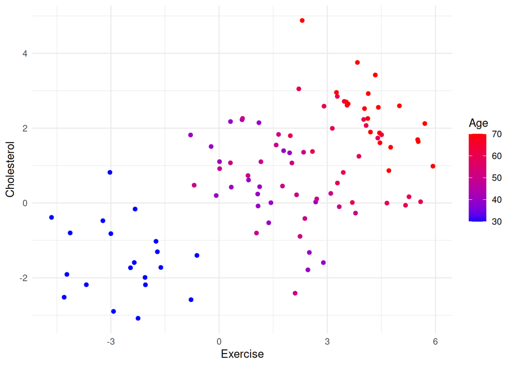

```r
#plot your data here

# Scatter of Cholesterol vs Exercise colored by Age
ggplot(exercise_data, aes(x = Exercise, y = Cholesterol, color = Age)) +
  geom_point() +
  scale_color_gradient(low = "blue", high = "red") +
  xlab("Exercise") +
  ylab("Cholesterol")
```

Simpson’s paradox is that within any given age (same color/band of points), more exercise is associated with LOWER cholesterol, which is what you’d expect. BUT across age groups, older people (red) both exercise more AND have higher cholesterol than younger people (blue). So when you ignore age and look at the whole cloud of points, the overall slope comes out positive because age is dragging the relationship the wrong way. The within-group effect is negative, the across-group effect (driven by age) is positive, and the across-group effect dominates the naive bivariate regression. Classic Simpson’s.

## Q9D. Draw a DAG using the daggity package to display how the variables of Cholesterol, Exercise, and Age are related. Call this dag “dag_9D”.

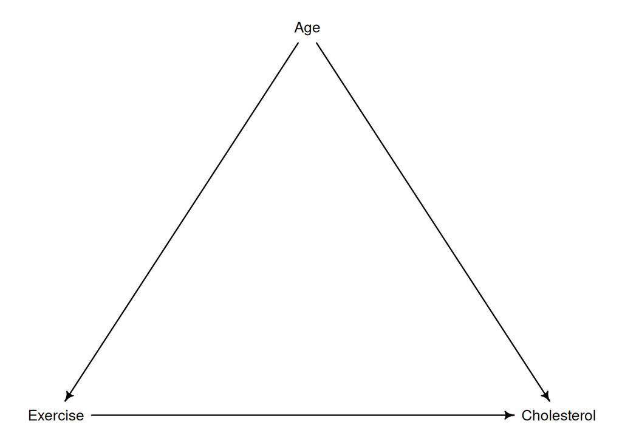

```r
#dag_9D

# Age drives both Exercise amount AND Cholesterol, and Exercise also drives Cholesterol
# So Age is a confounder on the Exercise -> Cholesterol relationship
dag_9D <- dagitty("dag{ Age -> Exercise; Age -> Cholesterol; Exercise -> Cholesterol}")
coordinates(dag_9D) <- list(x = c(Age = 1, Exercise = 0, Cholesterol = 2) , y = c(Age = 0, Exercise = 1, Cholesterol = 1))
drawdag(dag_9D)
```

## Q9E. Finally, reset your seed to 2026 and fit another Bayesian linear model that predicts Cholesterol (using Exercise and Age). Call this model “model_9E” and output the coefficients using precis. Do the results of this model make more sense than the model with only Exercise as a predictor?

```r
#model 9E

# Reset seed
set.seed(2026)

# Now include Age as a predictor to close the backdoor through Age
model_9E <- quap(
    alist(
        Cholesterol ~ dnorm(mu, sigma),
        mu <- a + bE  * Exercise + bA * Age,
        a  ~ dnorm(0, 0.2),
        bE ~ dnorm(0, 0.5),
        bA ~ dnorm(0, 0.5),
        sigma ~ dexp(1)
    ) , data = exercise_data_slim)

# Output coefficients
precis(model_9E)
```

```
##                mean         sd        5.5%       94.5%
## a     -0.0000154318 0.06205359 -0.09918905 0.099158183
## bE    -0.2032342406 0.13113252 -0.41280933 0.006340848
## bA     0.9059542513 0.13120108  0.69626958 1.115638924
## sigma  0.6527495985 0.04607979  0.57910519 0.726394006
```

*Write your answer in the lines below:*

Yes these make way more sense. Once Age is included, bE flips to negative: holding age constant, more exercise is associated with lower cholesterol, which matches what I expected. bA comes out positive, meaning older age is associated with higher cholesterol which also matches real-world patterns. So conditioning on the confounder (Age) reveals the true withinperson relationship between exercise and cholesterol, and the apparent paradox is resolved.

# Question 10: Stroop Data

We are going to reexamine the Stroop data with an eye towards what we can learn about the causal structure, based on regressions. To start, we will focus on the following variables: “RT”, “Condition”, and “young_or_old”.

## Q10A. First, draw a possible DAG that you think may describe the relationship between the 3 variables. Call this dag “dag_10A”. Are there any independencies between the variables, conditional or otherwise?

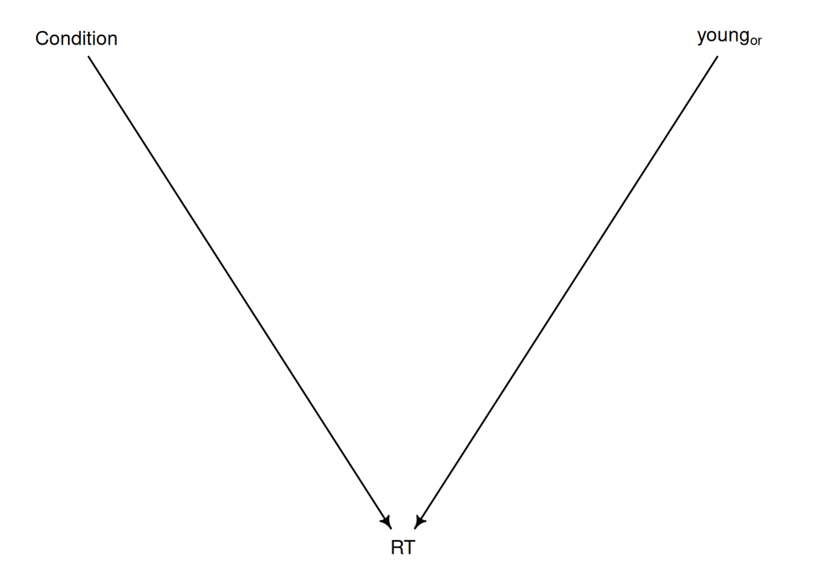

```r
#dag_10A

# Condition (congruent/incongruent) and young_or_old both affect RT directly
# young_or_old shouldn't affect Condition (trial condition is randomized within subjects),
# and Condition doesn't affect age obviously
dag_10A <- dagitty("dag{Condition -> RT; young_or_old -> RT}")
coordinates(dag_10A) <- list(x = c(Condition = 0, young_or_old = 2, RT = 1), y = c(Condition = 0, young_or_old = 0, RT = 1))
drawdag(dag_10A)
```

```r
# Check implied conditional independencie
impliedConditionalIndependencies(dag_10A)
```

```
## Cndt _||_ yn__
```

*Write your answer in the lines below:*

In this DAG, Condition and young_or_old are independent of each other (no arrow between them and no shared cause). RT depends on both. impliedConditionalIndependencies says Condition *||* young_or_old (i.e. they’re independent). They are NOT conditionally independent given RT because RT is a collider and conditioning on it would open a path between Condition and young_or_old.

## Q10B. Set your seed to 2026 and run a Bayesian regression using quap to predict RT from Condition and young_or_old. Make sure to standardize (z-score) RT! Call this model “model_10B” and output a summary of the posterior using precis. Do the results align with your DAG? Are they consistent with any alternative causal structures, for example, those with hidden variables?

```r
Stroop_Data <- read.csv('stroop_dataset_HW2.csv')

#model_10B

# Standardize RT (z-score)
Stroop_Data$RT_z <- scale(Stroop_Data$RT)

# Set seed
set.seed(2026)

# Data list for quap
stroop_slim <- list(
  RT_z         = as.numeric(Stroop_Data$RT_z),
  Condition    = Stroop_Data$Condition,
  young_or_old = Stroop_Data$young_or_old
)

# Fit model: RT_z ~ a + bC*Condition + bY*young_or_old
model_10B <- quap(
    alist(
        RT_z ~ dnorm( mu , sigma ) ,
        mu <- a + bC*Condition + bY*young_or_old ,
        a ~ dnorm(0 , 0.5),
        bC ~ dnorm(0 , 0.5),
        bY ~ dnorm(0 , 0.5),
        sigma ~ dexp(1)
    ) , data = stroop_slim )

# Summary
precis(model_10B)
```

```
##              mean          sd        5.5%       94.5%
## a     -0.11079301 0.017475714 -0.13872257 -0.08286344
## bC     0.16830808 0.021458231  0.13401368  0.20260247
## bY     0.06754152 0.021945796  0.03246789  0.10261514
## sigma  0.99577674 0.007594706  0.98363893  1.00791454
```

*Write your answer in the lines below:*

Both bC and bY come out positive and credible and incongruent trials have longer RT and older people have linger RT. This is consistent with my DAG (both Condition and young_or_old directly cause RT). These results are ALSO consistent with alternative DAGs that have hidden variables. For example, there could be a latent variable like “neural processing speed” that is influenced by age and influences RT, so young_or_old -> hidden -> RT would produce the same regression results. I can’t tell from this regression alone whether the effect of age on RT is direct or mediated by something else I havet measured.

Please see the Homework instructions document for more information about the new variable we will add to our model, “neural_accum”.